# Tutorial 8/Vaje 8

Peter Muršič

```r
library(tidyverse)
```

### EN

#### Intro

Solve by only using chains of pipe operators %>% to pass along dataframes and appropirate dplyr functions. Some of the appropriate dplyr functions: mutate, filter, group_by, summarise, select, arrange, rename, summarize, top_n, slice_max, sample_frac, slice_sample, ungroup, drop_na

#### A

In the dataframe airquality solve independently:

1. Show the rows without NA and the last 4 columns
2. Show 1/15th of the rows and only columns containing the letter “o”.
3. Add a new column, that shows temperature in Celsius and then show the max, min and average temparature
4. Find the safest and the most dangrerous day to sunbathe.

**Toggle output**

```r
airquality %>% drop_na () # to remove all NAs
```

```
##     Ozone Solar.R Wind Temp Month Day
## 1      41     190  7.4   67     5   1
## 2      36     118  8.0   72     5   2
## 3      12     149 12.6   74     5   3
## 4      18     313 11.5   62     5   4
## 5      23     299  8.6   65     5   7
## 6      19      99 13.8   59     5   8
## 7       8      19 20.1   61     5   9
## 8      16     256  9.7   69     5  12
## 9      11     290  9.2   66     5  13
## 10     14     274 10.9   68     5  14
## 11     18      65 13.2   58     5  15
## 12     14     334 11.5   64     5  16
## 13     34     307 12.0   66     5  17
## 14      6      78 18.4   57     5  18
```

[output cut: 97 more lines]

```r
airquality %>% filter(!is.na(Solar.R)) # remove NAs from only 1 column
```

```
##     Ozone Solar.R Wind Temp Month Day
## 1      41     190  7.4   67     5   1
## 2      36     118  8.0   72     5   2
## 3      12     149 12.6   74     5   3
## 4      18     313 11.5   62     5   4
## 5      23     299  8.6   65     5   7
## 6      19      99 13.8   59     5   8
## 7       8      19 20.1   61     5   9
## 8      NA     194  8.6   69     5  10
## 9      16     256  9.7   69     5  12
## 10     11     290  9.2   66     5  13
## 11     14     274 10.9   68     5  14
## 12     18      65 13.2   58     5  15
## 13     14     334 11.5   64     5  16
## 14     34     307 12.0   66     5  17
```

[output cut: 132 more lines]

```r
#airquality%>%slice_sample(n=nrow(.)/15)%>% select(grep("o",colnames(.)))
#airquality%>%.[sample(1:nrow(.),nrow(.)/15),]%>%.[,grep("o",colnames(.))]
#airquality%>%sample_frac(1/15)%>%select_if(grepl("o",colnames(.)))
airquality%>%slice_sample(prop=1/15) %>% select(contains("o"))
```

```
##    Ozone Solar.R Month
## 1     NA     258     7
## 2     24     238     9
## 3     89     229     8
## 4     36     139     9
## 5     47      95     9
## 6     NA     295     7
## 7     21     259     9
## 8     32      92     5
## 9     44     190     8
## 10    20      81     7
```

```r
#airquality %>% {.$Celsius<-(.$Temp-32)*5/9;.} %>% {data.frame(max=max(.$Celsius),min=min(.$Celsius),mean=mean(.$Celsius))}
airquality %>% mutate(Celsius=(Temp-32)*5/9) %>% summarize(max(Celsius),min(Celsius),mean(Celsius))
```

```
##   max(Celsius) min(Celsius) mean(Celsius)
## 1     36.11111     13.33333       25.4902
```

```r
airquality %>% filter(max(Solar.R,na.rm = T)==Solar.R | min(Solar.R,na.rm = T)==Solar.R)
```

```
##   Ozone Solar.R Wind Temp Month Day
## 1    14     334 11.5   64     5  16
## 2    16       7  6.9   74     7  21
```

#### B

In the dataframe mtcars:

1. By using rownames_to_column() add the rownames into a column names “Type”, save the new dataframe and from now on use the new one.
2. How much horsepower do the Mercedes brand cars have on average?
3. Count how many cars come in 4, 6 and 8 cylinders.
4. return the min and max value for each numerical column.

**Toggle output**

```r
#mtcars %>% rownames_to_column() %>% rename(Type=rowname)
#mtcars %>% mutate(Type=rownames(.))
mtcars %>% rownames_to_column("Type")->df
df %>% select(Type,hp) %>% filter(grepl("^Merc",Type)) %>% summarize(mean(hp))
```

```
##   mean(hp)
## 1 134.7143
```

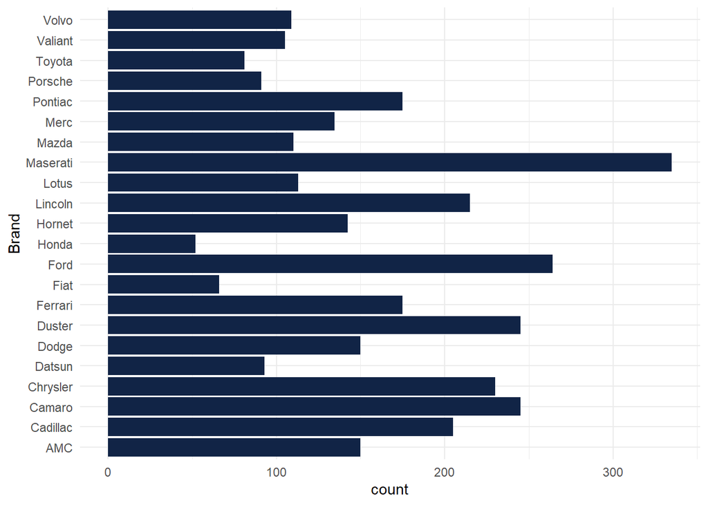

```r
  #{mean(.$hp)}
df %>% select(Type,hp) %>% mutate(Brand=str_remove(Type," .+$")) %>% group_by(Brand)%>%summarize(mean=mean(hp))->df2

df2 %>% ggplot() +
 aes(y =Brand , weight = mean) +
 geom_bar(fill = "#112446") +
 theme_minimal()
```

```r
df %>% group_by(cyl) %>% summarise(count=n()) %>% ungroup()
```

```
## # A tibble: 3 × 2
##     cyl count
##   <dbl> <int>
## 1     4    11
## 2     6     7
## 3     8    14
```

```r
#df %>% .[,sapply(.,class)=="numeric"]
#df %>% select(where(is.numeric))
df %>% select_if(sapply(.,class)=="numeric")%>% sapply(\(x){c(max(x),min(x))})
```

```
##       mpg cyl  disp  hp drat    wt qsec vs am gear carb
## [1,] 33.9   8 472.0 335 4.93 5.424 22.9  1  1    5    8
## [2,] 10.4   4  71.1  52 2.76 1.513 14.5  0  0    3    1
```

```r
df %>% summarise_if(is.numeric,c(max=max,min=min))
```

```
##   mpg_max cyl_max disp_max hp_max drat_max wt_max qsec_max vs_max am_max
## 1    33.9       8      472    335     4.93  5.424     22.9      1      1
##   gear_max carb_max mpg_min cyl_min disp_min hp_min drat_min wt_min qsec_min
## 1        5        8    10.4       4     71.1     52     2.76  1.513     14.5
##   vs_min am_min gear_min carb_min
## 1      0      0        3        1
```

#### C

In the dataframe USArrests

1. How many states are there in the USA?
2. Which are the top three most dangerous states in each of the arrest categories?
3. Sort the states based on the total number of arrests from all three crime categories.

**Toggle output**

```r
USArrests %>% head()
```

```
##            Murder Assault UrbanPop Rape
## Alabama      13.2     236       58 21.2
## Alaska       10.0     263       48 44.5
## Arizona       8.1     294       80 31.0
## Arkansas      8.8     190       50 19.5
## California    9.0     276       91 40.6
## Colorado      7.9     204       78 38.7
```

```r
USArrests %>% summarize(n())
```

```
##   n()
## 1  50
```

```r
USArrests %>% nrow()
```

```
## [1] 50
```

```r
#USArrests %>% slice_max(Rape,n=3) %>% rownames()
#USArrests %>% top_n(3,Murder)
USArrests %>% slice_max(Assault,n=3) %>% rownames()
```

```
## [1] "North Carolina" "Florida"        "Maryland"
```

```r
#USArrests %>% mutate(Skupno=Murder+Assault+Rape)%>% .[order(.$Skupno,decreasing = T),]
USArrests %>% mutate(Crime=Murder+Assault+Rape)%>%arrange(desc(Crime))
```

```
##                Murder Assault UrbanPop Rape Crime
## Florida          15.4     335       80 31.9 382.3
## North Carolina   13.0     337       45 16.1 366.1
## Maryland         11.3     300       67 27.8 339.1
## Arizona           8.1     294       80 31.0 333.1
## New Mexico       11.4     285       70 32.1 328.5
## California        9.0     276       91 40.6 325.6
## Alaska           10.0     263       48 44.5 317.5
## South Carolina   14.4     279       48 22.5 315.9
## Nevada           12.2     252       81 46.0 310.2
## Michigan         12.1     255       74 35.1 302.2
## Mississippi      16.1     259       44 17.1 292.2
## New York         11.1     254       86 26.1 291.2
## Louisiana        15.4     249       66 22.2 286.6
## Illinois         10.4     249       83 24.0 283.4
## Alabama          13.2     236       58 21.2 270.4
## Delaware          5.9     238       72 15.8 259.7
## Georgia          17.4     211       60 25.8 254.2
## Colorado          7.9     204       78 38.7 250.6
## Texas            12.7     201       80 25.5 239.2
## Tennessee        13.2     188       59 26.9 228.1
## Arkansas          8.8     190       50 19.5 218.3
## Missouri          9.0     178       70 28.2 215.2
## Oregon            4.9     159       67 29.3 193.2
## Rhode Island      3.4     174       87  8.3 185.7
## New Jersey        7.4     159       89 18.8 185.2
## Virginia          8.5     156       63 20.7 185.2
## Wyoming           6.8     161       60 15.6 183.4
## Oklahoma          6.6     151       68 20.0 177.6
## Washington        4.0     145       73 26.2 175.2
## Massachusetts     4.4     149       85 16.3 169.7
## Ohio              7.3     120       75 21.4 148.7
## Utah              3.2     120       80 22.9 146.1
## Indiana           7.2     113       65 21.0 141.2
## Kansas            6.0     115       66 18.0 139.0
## Idaho             2.6     120       54 14.2 136.8
## Kentucky          9.7     109       52 16.3 135.0
## Montana           6.0     109       53 16.4 131.4
## Pennsylvania      6.3     106       72 14.9 127.2
## Connecticut       3.3     110       77 11.1 124.4
## Nebraska          4.3     102       62 16.5 122.8
## South Dakota      3.8      86       45 12.8 102.6
## West Virginia     5.7      81       39  9.3  96.0
## Maine             2.1      83       51  7.8  92.9
## Minnesota         2.7      72       66 14.9  89.6
## Hawaii            5.3      46       83 20.2  71.5
## Iowa              2.2      56       57 11.3  69.5
## New Hampshire     2.1      57       56  9.5  68.6
## Wisconsin         2.6      53       66 10.8  66.4
## Vermont           2.2      48       32 11.2  61.4
## North Dakota      0.8      45       44  7.3  53.1
```

### SLO

#### Intro

Reši samo z uporabo verige funkcij in pipe %>%. Nekatere izmed primernih funkcij: mutate, filter, group_by, summarise, select, arrange, rename, summarize, top_n, slice_max, sample_frac, slice_sample, ungroup, drop_na

#### A

V dataframu airquality neodvisno od ostalih točk:

1. Prikaži vrstice brez NA in zadnje 4 stolpce
2. Prikaži samo eno petnajstino vrstic in stolpce, ki vsebujejo črko “o”.
3. Dodaj nov stolpec, ki prikazuje temperaturo v Celzijih. Nato prikaži najmanjšo, največjo in povprečno temperaturo v celzijih.
4. Najdi najbolj varen in najbolj nevaren dan za sončenje.

**Toggle output**

```r
#1
#airquality %>% .[!is.na(.$Ozone),ncol(.)-3:0]
airquality %>% drop_na()
```

```
##     Ozone Solar.R Wind Temp Month Day
## 1      41     190  7.4   67     5   1
## 2      36     118  8.0   72     5   2
## 3      12     149 12.6   74     5   3
## 4      18     313 11.5   62     5   4
## 5      23     299  8.6   65     5   7
## 6      19      99 13.8   59     5   8
## 7       8      19 20.1   61     5   9
## 8      16     256  9.7   69     5  12
## 9      11     290  9.2   66     5  13
## 10     14     274 10.9   68     5  14
## 11     18      65 13.2   58     5  15
## 12     14     334 11.5   64     5  16
## 13     34     307 12.0   66     5  17
## 14      6      78 18.4   57     5  18
```

[output cut: 97 more lines]

```r
airquality %>% filter(!is.na(Ozone)) %>% select(Wind:Day)
```

```
##     Wind Temp Month Day
## 1    7.4   67     5   1
## 2    8.0   72     5   2
## 3   12.6   74     5   3
## 4   11.5   62     5   4
## 5   14.9   66     5   6
## 6    8.6   65     5   7
## 7   13.8   59     5   8
## 8   20.1   61     5   9
## 9    6.9   74     5  11
## 10   9.7   69     5  12
## 11   9.2   66     5  13
## 12  10.9   68     5  14
## 13  13.2   58     5  15
## 14  11.5   64     5  16
```

[output cut: 102 more lines]

```r
#2
#airquality %>% sample_frac(1/15)
#airquality %>% slice_sample(n=nrow(.)/15)
#airquality %>% .[sample(1:nrow(.),nrow(.)/15),]
airquality %>% slice_sample(prop=1/15)
```

```
##    Ozone Solar.R Wind Temp Month Day
## 1     NA     137 11.5   86     8  11
## 2     36     118  8.0   72     5   2
## 3     18     313 11.5   62     5   4
## 4     16      77  7.4   82     8   3
## 5     NA      NA 14.3   56     5   5
## 6     44     190 10.3   78     8  20
## 7     35     274 10.3   82     7  17
## 8     23      13 12.0   67     5  28
## 9     23     148  8.0   82     6  13
## 10    24     259  9.7   73     9  10
```

```r
#airquality %>% select_if(grepl("o",colnames(.)))
#airquality %>% select(grep("o",colnames(.)))
#airquality %>% .[,grep("o",colnames(.))]
airquality %>% select(contains("o"))
```

```
##     Ozone Solar.R Month
## 1      41     190     5
## 2      36     118     5
## 3      12     149     5
## 4      18     313     5
## 5      NA      NA     5
## 6      28      NA     5
## 7      23     299     5
## 8      19      99     5
## 9       8      19     5
## 10     NA     194     5
## 11      7      NA     5
## 12     16     256     5
## 13     11     290     5
## 14     14     274     5
```

[output cut: 139 more lines]

```r
#3
airquality %>% {.["Celzij"]<-(.$Temp-32)*5/9;.}
```

```
##     Ozone Solar.R Wind Temp Month Day   Celzij
## 1      41     190  7.4   67     5   1 19.44444
## 2      36     118  8.0   72     5   2 22.22222
## 3      12     149 12.6   74     5   3 23.33333
## 4      18     313 11.5   62     5   4 16.66667
## 5      NA      NA 14.3   56     5   5 13.33333
## 6      28      NA 14.9   66     5   6 18.88889
## 7      23     299  8.6   65     5   7 18.33333
## 8      19      99 13.8   59     5   8 15.00000
## 9       8      19 20.1   61     5   9 16.11111
## 10     NA     194  8.6   69     5  10 20.55556
## 11      7      NA  6.9   74     5  11 23.33333
## 12     16     256  9.7   69     5  12 20.55556
## 13     11     290  9.2   66     5  13 18.88889
## 14     14     274 10.9   68     5  14 20.00000
```

[output cut: 139 more lines]

```r
airquality %>% {.$Celzij<-(.$Temp-32)*5/9;.}
```

```
##     Ozone Solar.R Wind Temp Month Day   Celzij
## 1      41     190  7.4   67     5   1 19.44444
## 2      36     118  8.0   72     5   2 22.22222
## 3      12     149 12.6   74     5   3 23.33333
## 4      18     313 11.5   62     5   4 16.66667
## 5      NA      NA 14.3   56     5   5 13.33333
## 6      28      NA 14.9   66     5   6 18.88889
## 7      23     299  8.6   65     5   7 18.33333
## 8      19      99 13.8   59     5   8 15.00000
## 9       8      19 20.1   61     5   9 16.11111
## 10     NA     194  8.6   69     5  10 20.55556
## 11      7      NA  6.9   74     5  11 23.33333
## 12     16     256  9.7   69     5  12 20.55556
## 13     11     290  9.2   66     5  13 18.88889
## 14     14     274 10.9   68     5  14 20.00000
```

[output cut: 139 more lines]

```r
airquality %>% mutate(Celzij=(Temp-32)*5/9)
```

```
##     Ozone Solar.R Wind Temp Month Day   Celzij
## 1      41     190  7.4   67     5   1 19.44444
## 2      36     118  8.0   72     5   2 22.22222
## 3      12     149 12.6   74     5   3 23.33333
## 4      18     313 11.5   62     5   4 16.66667
## 5      NA      NA 14.3   56     5   5 13.33333
## 6      28      NA 14.9   66     5   6 18.88889
## 7      23     299  8.6   65     5   7 18.33333
## 8      19      99 13.8   59     5   8 15.00000
## 9       8      19 20.1   61     5   9 16.11111
## 10     NA     194  8.6   69     5  10 20.55556
## 11      7      NA  6.9   74     5  11 23.33333
## 12     16     256  9.7   69     5  12 20.55556
## 13     11     290  9.2   66     5  13 18.88889
## 14     14     274 10.9   68     5  14 20.00000
```

[output cut: 139 more lines]

```r
#airquality %>% {data.frame(min=min(.$Temp),max=max(.$Temp),mean=mean(.$Temp))}
airquality %>% summarize(min=min(Temp),max(Temp),mean(Temp))
```

```
##   min max(Temp) mean(Temp)
## 1  56        97   77.88235
```

```r
#A4
airquality %>% filter(max(Solar.R,na.rm = T)==Solar.R | min(Solar.R,na.rm = T)==Solar.R)
```

```
##   Ozone Solar.R Wind Temp Month Day
## 1    14     334 11.5   64     5  16
## 2    16       7  6.9   74     7  21
```

#### B

V dataframu mtcars:

1. Z uporabo rownames_to_column() dodaj imena avtomobilov v nov stolpec z imenom “Tip”, ga shrani in od tukaj dalje delaj na tem dataframu
2. Koliko konjske moči imajo v povprečju avtomobili znamke Mercedes?
3. Preštej koliko avtov ima 4,6, in 8 cilindrov.
4. Vrni maximalno in minimalno vrednost za vsak numerični stolpec.

**Toggle output**

```r
#mtcars %>% mutate(Tip=rownames(.))
#mtcars %>% rownames_to_column("Tip")
mtcars %>% rownames_to_column() %>% rename(Tip=rowname) ->df;df
```

```
##                    Tip  mpg cyl  disp  hp drat    wt  qsec vs am gear carb
## 1            Mazda RX4 21.0   6 160.0 110 3.90 2.620 16.46  0  1    4    4
## 2        Mazda RX4 Wag 21.0   6 160.0 110 3.90 2.875 17.02  0  1    4    4
## 3           Datsun 710 22.8   4 108.0  93 3.85 2.320 18.61  1  1    4    1
## 4       Hornet 4 Drive 21.4   6 258.0 110 3.08 3.215 19.44  1  0    3    1
## 5    Hornet Sportabout 18.7   8 360.0 175 3.15 3.440 17.02  0  0    3    2
## 6              Valiant 18.1   6 225.0 105 2.76 3.460 20.22  1  0    3    1
## 7           Duster 360 14.3   8 360.0 245 3.21 3.570 15.84  0  0    3    4
## 8            Merc 240D 24.4   4 146.7  62 3.69 3.190 20.00  1  0    4    2
## 9             Merc 230 22.8   4 140.8  95 3.92 3.150 22.90  1  0    4    2
## 10            Merc 280 19.2   6 167.6 123 3.92 3.440 18.30  1  0    4    4
## 11           Merc 280C 17.8   6 167.6 123 3.92 3.440 18.90  1  0    4    4
## 12          Merc 450SE 16.4   8 275.8 180 3.07 4.070 17.40  0  0    3    3
## 13          Merc 450SL 17.3   8 275.8 180 3.07 3.730 17.60  0  0    3    3
## 14         Merc 450SLC 15.2   8 275.8 180 3.07 3.780 18.00  0  0    3    3
```

[output cut: 18 more lines]

```r
df %>% filter(grepl("Merc",Tip)) %>% summarize(mean(hp))
```

```
##   mean(hp)
## 1 134.7143
```

```r
df %>% mutate(Znamka=str_remove(Tip," .*$")) %>% group_by(Znamka) %>% summarize(mean(hp)) %>% ungroup()
```

```
## # A tibble: 22 × 2
##    Znamka   `mean(hp)`
##    <chr>         <dbl>
##  1 AMC             150
##  2 Cadillac        205
##  3 Camaro          245
##  4 Chrysler        230
##  5 Datsun           93
##  6 Dodge           150
##  7 Duster          245
##  8 Ferrari         175
##  9 Fiat             66
## 10 Ford            264
## # ℹ 12 more rows
```

```r
df%>%head()
```

```
##                 Tip  mpg cyl disp  hp drat    wt  qsec vs am gear carb
## 1         Mazda RX4 21.0   6  160 110 3.90 2.620 16.46  0  1    4    4
## 2     Mazda RX4 Wag 21.0   6  160 110 3.90 2.875 17.02  0  1    4    4
## 3        Datsun 710 22.8   4  108  93 3.85 2.320 18.61  1  1    4    1
## 4    Hornet 4 Drive 21.4   6  258 110 3.08 3.215 19.44  1  0    3    1
## 5 Hornet Sportabout 18.7   8  360 175 3.15 3.440 17.02  0  0    3    2
## 6           Valiant 18.1   6  225 105 2.76 3.460 20.22  1  0    3    1
```

```r
df %>% group_by(cyl) %>% summarise(count=n()) %>% ungroup()->df2

df%>%inner_join(df2,by=c("cyl"="cyl"))
```

```
##                    Tip  mpg cyl  disp  hp drat    wt  qsec vs am gear carb
## 1            Mazda RX4 21.0   6 160.0 110 3.90 2.620 16.46  0  1    4    4
## 2        Mazda RX4 Wag 21.0   6 160.0 110 3.90 2.875 17.02  0  1    4    4
## 3           Datsun 710 22.8   4 108.0  93 3.85 2.320 18.61  1  1    4    1
## 4       Hornet 4 Drive 21.4   6 258.0 110 3.08 3.215 19.44  1  0    3    1
## 5    Hornet Sportabout 18.7   8 360.0 175 3.15 3.440 17.02  0  0    3    2
## 6              Valiant 18.1   6 225.0 105 2.76 3.460 20.22  1  0    3    1
## 7           Duster 360 14.3   8 360.0 245 3.21 3.570 15.84  0  0    3    4
## 8            Merc 240D 24.4   4 146.7  62 3.69 3.190 20.00  1  0    4    2
## 9             Merc 230 22.8   4 140.8  95 3.92 3.150 22.90  1  0    4    2
## 10            Merc 280 19.2   6 167.6 123 3.92 3.440 18.30  1  0    4    4
## 11           Merc 280C 17.8   6 167.6 123 3.92 3.440 18.90  1  0    4    4
## 12          Merc 450SE 16.4   8 275.8 180 3.07 4.070 17.40  0  0    3    3
## 13          Merc 450SL 17.3   8 275.8 180 3.07 3.730 17.60  0  0    3    3
## 14         Merc 450SLC 15.2   8 275.8 180 3.07 3.780 18.00  0  0    3    3
```

[output cut: 51 more lines]

```r
df %>% group_by(cyl) %>% inner_join(summarise(.,count=n()),by=c("cyl"="cyl")) %>% ungroup()  #studenti so zeleli vedeti kako se to naredi
```

```
## # A tibble: 32 × 13
##    Tip     mpg   cyl  disp    hp  drat    wt  qsec    vs    am  gear  carb count
##    <chr> <dbl> <dbl> <dbl> <dbl> <dbl> <dbl> <dbl> <dbl> <dbl> <dbl> <dbl> <int>
##  1 Mazd…  21       6  160    110  3.9   2.62  16.5     0     1     4     4     7
##  2 Mazd…  21       6  160    110  3.9   2.88  17.0     0     1     4     4     7
##  3 Dats…  22.8     4  108     93  3.85  2.32  18.6     1     1     4     1    11
##  4 Horn…  21.4     6  258    110  3.08  3.22  19.4     1     0     3     1     7
##  5 Horn…  18.7     8  360    175  3.15  3.44  17.0     0     0     3     2    14
##  6 Vali…  18.1     6  225    105  2.76  3.46  20.2     1     0     3     1     7
##  7 Dust…  14.3     8  360    245  3.21  3.57  15.8     0     0     3     4    14
##  8 Merc…  24.4     4  147.    62  3.69  3.19  20       1     0     4     2    11
##  9 Merc…  22.8     4  141.    95  3.92  3.15  22.9     1     0     4     2    11
## 10 Merc…  19.2     6  168.   123  3.92  3.44  18.3     1     0     4     4     7
## # ℹ 22 more rows
```

```r
df %>% .[,sapply(.,class)=="numeric"]
```

```
##     mpg cyl  disp  hp drat    wt  qsec vs am gear carb
## 1  21.0   6 160.0 110 3.90 2.620 16.46  0  1    4    4
## 2  21.0   6 160.0 110 3.90 2.875 17.02  0  1    4    4
## 3  22.8   4 108.0  93 3.85 2.320 18.61  1  1    4    1
## 4  21.4   6 258.0 110 3.08 3.215 19.44  1  0    3    1
## 5  18.7   8 360.0 175 3.15 3.440 17.02  0  0    3    2
## 6  18.1   6 225.0 105 2.76 3.460 20.22  1  0    3    1
## 7  14.3   8 360.0 245 3.21 3.570 15.84  0  0    3    4
## 8  24.4   4 146.7  62 3.69 3.190 20.00  1  0    4    2
## 9  22.8   4 140.8  95 3.92 3.150 22.90  1  0    4    2
## 10 19.2   6 167.6 123 3.92 3.440 18.30  1  0    4    4
## 11 17.8   6 167.6 123 3.92 3.440 18.90  1  0    4    4
## 12 16.4   8 275.8 180 3.07 4.070 17.40  0  0    3    3
## 13 17.3   8 275.8 180 3.07 3.730 17.60  0  0    3    3
## 14 15.2   8 275.8 180 3.07 3.780 18.00  0  0    3    3
```

[output cut: 18 more lines]

```r
df %>% select_if(sapply(.,class)=="numeric")%>% sapply(\(x){c(max(x),min(x))})
```

```
##       mpg cyl  disp  hp drat    wt qsec vs am gear carb
## [1,] 33.9   8 472.0 335 4.93 5.424 22.9  1  1    5    8
## [2,] 10.4   4  71.1  52 2.76 1.513 14.5  0  0    3    1
```

```r
df %>% summarise_if(is.numeric,c(max=max,min=min))
```

```
##   mpg_max cyl_max disp_max hp_max drat_max wt_max qsec_max vs_max am_max
## 1    33.9       8      472    335     4.93  5.424     22.9      1      1
##   gear_max carb_max mpg_min cyl_min disp_min hp_min drat_min wt_min qsec_min
## 1        5        8    10.4       4     71.1     52     2.76  1.513     14.5
##   vs_min am_min gear_min carb_min
## 1      0      0        3        1
```

```r
df %>% select(where(is.numeric))
```

```
##     mpg cyl  disp  hp drat    wt  qsec vs am gear carb
## 1  21.0   6 160.0 110 3.90 2.620 16.46  0  1    4    4
## 2  21.0   6 160.0 110 3.90 2.875 17.02  0  1    4    4
## 3  22.8   4 108.0  93 3.85 2.320 18.61  1  1    4    1
## 4  21.4   6 258.0 110 3.08 3.215 19.44  1  0    3    1
## 5  18.7   8 360.0 175 3.15 3.440 17.02  0  0    3    2
## 6  18.1   6 225.0 105 2.76 3.460 20.22  1  0    3    1
## 7  14.3   8 360.0 245 3.21 3.570 15.84  0  0    3    4
## 8  24.4   4 146.7  62 3.69 3.190 20.00  1  0    4    2
## 9  22.8   4 140.8  95 3.92 3.150 22.90  1  0    4    2
## 10 19.2   6 167.6 123 3.92 3.440 18.30  1  0    4    4
## 11 17.8   6 167.6 123 3.92 3.440 18.90  1  0    4    4
## 12 16.4   8 275.8 180 3.07 4.070 17.40  0  0    3    3
## 13 17.3   8 275.8 180 3.07 3.730 17.60  0  0    3    3
## 14 15.2   8 275.8 180 3.07 3.780 18.00  0  0    3    3
```

[output cut: 18 more lines]

#### C

V dataframeu USArrests

1. Koliko zveznih držav ima ZDA?
2. Katere tri zvezne države so najbolj nevarne v vsakem izmed treh katogorij kriminala?
3. Razvsrti zvezne države glede na skupno vrednost aretacij vseh treh kriminalnih dejavnosti.

**Toggle output**

```r
USArrests %>% head()
```

```
##            Murder Assault UrbanPop Rape
## Alabama      13.2     236       58 21.2
## Alaska       10.0     263       48 44.5
## Arizona       8.1     294       80 31.0
## Arkansas      8.8     190       50 19.5
## California    9.0     276       91 40.6
## Colorado      7.9     204       78 38.7
```

```r
USArrests %>% summarize(n())
```

```
##   n()
## 1  50
```

```r
USArrests %>% nrow()
```

```
## [1] 50
```

```r
#USArrests %>% slice_max(Rape,n=3) %>% rownames()
#USArrests %>% top_n(3,Murder)
USArrests %>% slice_max(Assault,n=3) %>% rownames()
```

```
## [1] "North Carolina" "Florida"        "Maryland"
```

```r
#USArrests %>% mutate(Skupno=Murder+Assault+Rape)%>% .[order(.$Skupno,decreasing = T),]
USArrests %>% mutate(Skupno=Murder+Assault+Rape)%>%arrange(desc(Skupno))
```

```
##                Murder Assault UrbanPop Rape Skupno
## Florida          15.4     335       80 31.9  382.3
## North Carolina   13.0     337       45 16.1  366.1
## Maryland         11.3     300       67 27.8  339.1
## Arizona           8.1     294       80 31.0  333.1
## New Mexico       11.4     285       70 32.1  328.5
## California        9.0     276       91 40.6  325.6
## Alaska           10.0     263       48 44.5  317.5
## South Carolina   14.4     279       48 22.5  315.9
## Nevada           12.2     252       81 46.0  310.2
## Michigan         12.1     255       74 35.1  302.2
## Mississippi      16.1     259       44 17.1  292.2
## New York         11.1     254       86 26.1  291.2
## Louisiana        15.4     249       66 22.2  286.6
## Illinois         10.4     249       83 24.0  283.4
## Alabama          13.2     236       58 21.2  270.4
## Delaware          5.9     238       72 15.8  259.7
## Georgia          17.4     211       60 25.8  254.2
## Colorado          7.9     204       78 38.7  250.6
## Texas            12.7     201       80 25.5  239.2
## Tennessee        13.2     188       59 26.9  228.1
## Arkansas          8.8     190       50 19.5  218.3
## Missouri          9.0     178       70 28.2  215.2
## Oregon            4.9     159       67 29.3  193.2
## Rhode Island      3.4     174       87  8.3  185.7
## New Jersey        7.4     159       89 18.8  185.2
## Virginia          8.5     156       63 20.7  185.2
## Wyoming           6.8     161       60 15.6  183.4
## Oklahoma          6.6     151       68 20.0  177.6
## Washington        4.0     145       73 26.2  175.2
## Massachusetts     4.4     149       85 16.3  169.7
## Ohio              7.3     120       75 21.4  148.7
## Utah              3.2     120       80 22.9  146.1
## Indiana           7.2     113       65 21.0  141.2
## Kansas            6.0     115       66 18.0  139.0
## Idaho             2.6     120       54 14.2  136.8
## Kentucky          9.7     109       52 16.3  135.0
## Montana           6.0     109       53 16.4  131.4
## Pennsylvania      6.3     106       72 14.9  127.2
## Connecticut       3.3     110       77 11.1  124.4
## Nebraska          4.3     102       62 16.5  122.8
## South Dakota      3.8      86       45 12.8  102.6
## West Virginia     5.7      81       39  9.3   96.0
## Maine             2.1      83       51  7.8   92.9
## Minnesota         2.7      72       66 14.9   89.6
## Hawaii            5.3      46       83 20.2   71.5
## Iowa              2.2      56       57 11.3   69.5
## New Hampshire     2.1      57       56  9.5   68.6
## Wisconsin         2.6      53       66 10.8   66.4
## Vermont           2.2      48       32 11.2   61.4
## North Dakota      0.8      45       44  7.3   53.1
```